# X-ray crystal structure of trans-bis(pyridin-3-yl)ethylene: comparing the supramolecular structural features among the symmetrical bis(n-pyridyl)ethylenes (n = 2, 3, or 4) constitutional isomers

Author

Jay Quentin, Eric W. Reinheimer and Leonard R. MacGillivray*

The molecular structure of *trans*-bis(pyridin-3-yl)ethylene (**3,3′-bpe**), C<sub>12</sub>H<sub>10</sub>N<sub>2</sub>, as determined by single-crystal X-ray diffraction is reported. The molecule self-assembles into two dimensional arrays by a combination of C—H⋯N hydrogen bonds and edge-to-face C—H⋯*π* interactions that stack in a herringbone arrangement perpendicular to the crystallographic *c*-axis. The supramolecular forces that direct the packing of **3,3′-bpe** as well as its packing assembly within the crystal are also compared to those observed within the structures of the other symmetrical isomers *trans*-1,2-bis(*n*-pyridyl)ethylene (*n*,*n*′-bpe, where *n* = *n*′ = 2 or 4).

## 1. Chemical context

Bis(pyridyl)ethylenes have arisen as somewhat of a natural extension of cinnamic acid as a series of molecules capable of undergoing [2+2] photodimerization in the solid state to generate cyclobutanes. Foundational work by Schmidt and coworkers on *trans*-cinnamic acids led to the formation of the `Topochemical Postulate’, which dictated that [olefins](http://goldbook.iupac.org/O04281.html) within 4.2 Å of one another are capable of undergoing the photodimerization process. Unlike cinnamic acid, which crystallizes in such a way that the [olefins](http://goldbook.iupac.org/O04281.html) are rendered photoactive (olefins within 4.2 Å of one another), the native crystalline forms of bis(pyridyl)ethylenes are photostable (olefins separated by distances > 4.2 Å in the crystal). To achieve photoreactivity of these [olefins,](http://goldbook.iupac.org/O04281.html) it often becomes necessary to use a `molecular template’ that can interact with the olefin-containing bipyridine *via* supramolecular interactions such as hydrogen bonding, halogen bonding, argento- and aurophilic interactions, and dative N→B interactions. Analyses of the crystal structures of symmetric bis(pyridyl)ethylenes derivatives such as the *trans*-bis(*n*-pyridyl)ethylenes series of isomers (*n* = 2, 3 or 4) is necessary to understand the forces that govern their crystallization, why they are photostable, and why use templates to achieve photoreactivity (Campillo-Alvarado *et al.*, 2019; Chanthapally *et al.*, 2014; MacGillivray *et al.*, 2008; Pahari *et al.*, 2019; Sezer *et al.*, 2017; Volodin *et al.*, 2018).

## 2. Structural commentary

The alkene **3,3′-bpe** crystallizes in the centrosymmetric monoclinic [space group](http://reference.iucr.org/dictionary/Space_group) *P*2<sub>1</sub>/*n* (Fig. 1). The [asymmetric unit](http://reference.iucr.org/dictionary/Asymmetric_unit) consists of one-half molecule of **3,3′-bpe** with the C=C bond sitting on a crystallographic center of inversion. The pyridyl rings adopt an *anti*-conformation with respect to each other (Fig. 1).

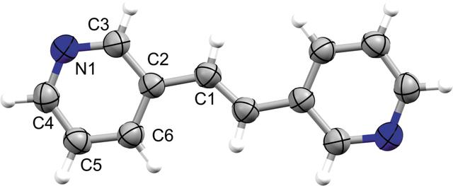

Single crystal structure for trans-bis(pyridin-3-yl)ethylene (3,3′-bpe) with anisotropic displacement ellipsoids at 50% probability.

## 3. Supramolecular features

Adjacent **3,3′-bpe** molecules interact primarily *via* edge-to-face C—H⋯*π*[*d*(C6⋯pyr) 3.58 Å; *Θ*(C6—H6⋯pyr) 131.8°] forces between pyridyl rings (Fig. 2). Those rings also participate in C—H⋯N [*d*(C4⋯N1) 3.59 Å; *Θ*(C4—H4⋯N1) 139.5°] hydrogen bonds (Fig. 2). The forces generate nearly planar sheets (Fig. 3), which aggregate into a herringbone arrangement of adjacent sheets (Fig. 4). Nearest-neighbor alkene C=C bonds of **3,3′-bpe** between adjacent sheets reveals a parallel, but offset orientation of the neighboring [alkenes](http://goldbook.iupac.org/A00224.html) relative to one another at a distance of 5.50 Å. The distance exceeds the inter-alkene separation of Schmidt for photodimerizarion and suggests that **3,3′-bpe** is photostable (Schmidt, 1971).

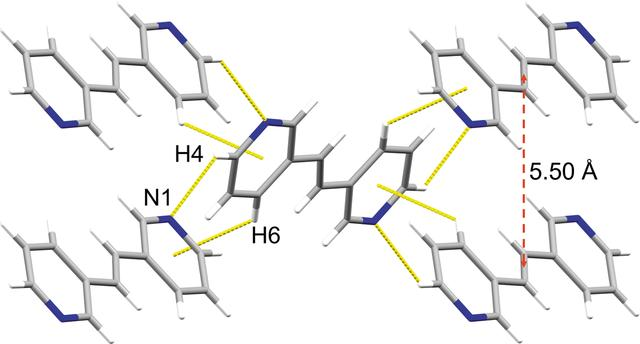

C—H⋯N and edge-to-face C—H⋯π intermolecular interactions (both yellow dotted lines) highlighting nearest-neighbor alkene separations (red dashed arrow) (view along a).

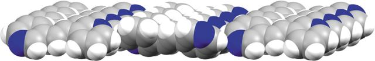

Edge-on view of sheets encompassing neighboring molecules of 3,3′-bpe supported by C—H⋯N and C—H⋯π intermolecular interactions.

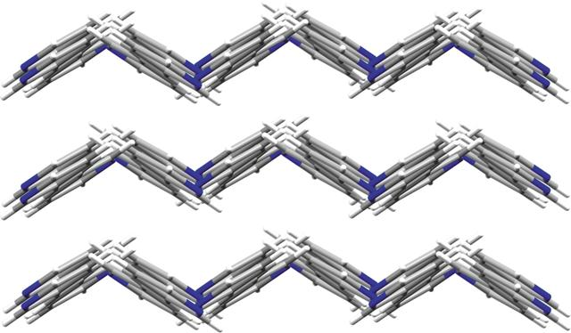

Herringbone arrangement of neighboring sheets of 3,3′-bpe molecules.

## 4. Database survey

For the *n*,*n*′-bpe (where: *n* = *n*′ = 2, 3, or 4) series of symmetric [alkenes,](http://goldbook.iupac.org/A00224.html) all three adopt nearly planar conformations (Table 1), with the pyridyl rings of **3,3′-bpe** and **2,2′-bpe** adopting *anti*-conformations with respect to each other. The packings of the symmetric [alkenes](http://goldbook.iupac.org/A00224.html) are defined by combinations of C—H⋯*π* and/or C—H⋯N hydrogen bonds (Table 1) to form either one-dimensional chain (**2,2′-bpe**, Fig. 5) or two-dimensional sheet (**3,3′-bpe** and **4,4′-bpe**) structures (Fig. 6). Similar to **3,3′-bpe**, the alkene C=C bonds of **2,2′-bpe** (6.09 Å; Vansant *et al.*, 1980) and **4,4′-bpe** (5.72 Å; Tinnemans *et al.*, 2018) (Table 1) are beyond the separation distance of Schmidt (1971).

| Compound | 2,2′-bpe | 3,3′-bpe | 4,4′-bpe |
| --- | --- | --- | --- |
| Twist angle φ (°) | 7.43 | 5.17 | 9.14 |
| Solid-state packing assembly | corrugated chains | approximately planar sheets | planar sheets |
| Assembly forces | edge-to-face C—H⋯π | edge-to-face C—H⋯π, C—H⋯N | C—H⋯N, face-to-face π–π |
| Nearest-neighbor alkene separation (Å) | 6.09 | 5.5 | 5.72 |

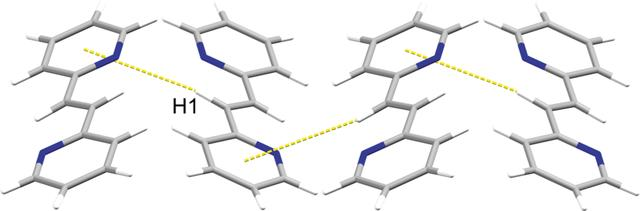

Corrugated, one-dimensional chains of 2,2′-bpe.

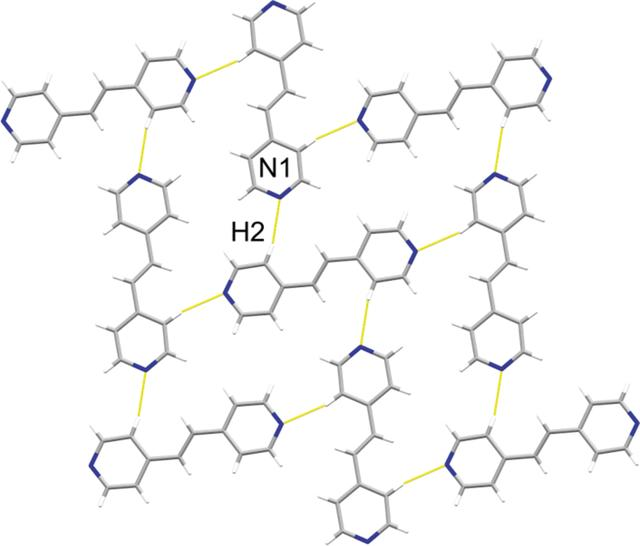

Planar, two-dimensional sheets of 4,4′-bpe.

## 5. Synthesis and crystallization

The alkene **3,3′-bpe** was prepared as described (Quentin *et al.*, 2020; Gordillo *et al.*, 2007, 2013) via a one-pot, aqueous Pd-catalyzed Hiyama-Heck cross-coupling between 3-bromopyridine and triethoxyvinylsilane (2:1 molar ratio) (Fig. 7). Flash [chromatography](http://goldbook.iupac.org/C01075.html) (SiO<sub>2</sub>, 10% MeOH/CH<sub>2</sub>Cl<sub>2</sub>) furnished **3,3′-bpe** as yellow crystals: 222.3 mg (23%). A portion of **3,3′-bpe** was dissolved in CHCl<sub>3</sub> and allowed to slowly evaporate at room temperature. Single crystals in the form of colorless plates suitable for single crystal X-ray diffraction formed within seven days.

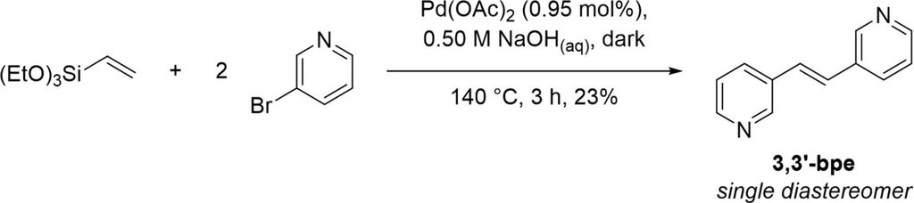

Synthesis of 3,3’ bpe via Pd-catalyzed Hiyama–Heck cross-coupling.

## 6. Refinement

Crystal data, data collection and structure [refinement](http://reference.iucr.org/dictionary/Refinement) details for **3,3′-bpe** are summarized in Table 2. All non-hydrogen atoms were refined anisotropically. Hydrogen atoms were located in the difference-Fourier map and freely refined with 0.93 < C—H < 0.99 Å. Refinement of the hydrogen atoms led to a data-to-parameter ratio of ∼10. The single-crystal data were collected at room temperature to best reflect conditions under which photochemical reactions are typically conducted. Room-temperature data can also lead to fewer reflections and/or scaling anomalies.

| Crystal data | Information |
| --- | --- |
| Chemical formula | C12H10N2 |
| Mr | 182.22 |
| Crystal system, space group | Monoclinic, P21/n |
| Temperature (K) | 296 |
| a, b, c (Å) | 7.4591 (7), 5.5045 (6), 11.7803 (12) |
| β (°) | 99.638 (5) |
| V (Å3) | 476.86 (8) |
| Z | 2 |
| Radiation type | Mo Kα |
| μ (mm−1) | 0.08 |
| Crystal size (mm) | 0.18 × 0.12 × 0.06 |
| NA | NA |
| Data collection | NA |
| Diffractometer | Bruker Nonius KappaCCD |
| Absorption correction | Multi-scan (SADABS; Krause et al., 2015) |
| Tmin, Tmax | 0.989, 0.995 |
| No. of measured, independent and observed [I > 2σ(I)] reflections | 2410, 836, 587 |
| Rint | 3.4000000000000002E-2 |
| NA | NA |
| Refinement | NA |
| R[F2 > 2σ(F2)], wR(F2), S | 0.050, 0.137, 1.07 |
| No. of reflections | 836 |
| No. of parameters | 84 |
| H-atom treatment | All H-atom parameters refined |
| Δρmax, Δρmin (e Å−3) | 0.13, −0.16 |